# Práctica Breast Cancer

## Descripción

Realizar un modelo de aprendizaje supervisado con el algoritmo KNeighbors. Una vez creado el modelo evaluarlo a través de una matriz de confusión y tabla de clasificación.

### Cargamos los datos

```python
from sklearn.datasets import load_breast_cancer
breast_cancer = load_breast_cancer()
```

### Importamos las librerias necesarias

```python
import numpy as np
import pandas as pd
import matplotlib.pyplot as plt
import seaborn as sns
import warnings
warnings.simplefilter(action='ignore', category=FutureWarning)
warnings.filterwarnings('ignore')
```

### Inspeccionamos la descripción de los datos

```python
breast_cancer.DESCR
```

```
'.. _breast_cancer_dataset:\n\nBreast cancer wisconsin (diagnostic) dataset\n--------------------------------------------\n\n**Data Set Characteristics:**\n\n    :Number of Instances: 569\n\n    :Number of Attributes: 30 numeric, predictive attributes and the class\n\n    :Attribute Information:\n  …
```

Características fundamentales:

- 569 instancias
- 30 atributos
- No existen valores nulos
- Distribución de clases con 212 Malignant, 357 Bening

La inexistencia de valores nulos nos facilita el preprocesamiento ya que en caso contrario deberíamos de utilizar algún método de imputación de variables o eliminación de instancias.

### Obtenemos las claves del dataset.

Las claves del dataset nos permiten obtener el contenido dentro de este de una forma categorizada.

```python
breast_cancer.keys()
```

```
dict_keys(['data', 'target', 'frame', 'target_names', 'DESCR', 'feature_names', 'filename', 'data_module'])
```

#### Como los nombres de las clases

```python
breast_cancer.target_names
```

```
array(['malignant', 'benign'], dtype='<U9')
```

#### O los nombres de los atributos

```python
breast_cancer.feature_names
```

```
array(['mean radius', 'mean texture', 'mean perimeter', 'mean area',
       'mean smoothness', 'mean compactness', 'mean concavity',
       'mean concave points', 'mean symmetry', 'mean fractal dimension',
       'radius error', 'texture error', 'perimeter error', 'area error',
       'smoothness error', 'compactness error', 'concavity error',
       'concave points error', 'symmetry error',
       'fractal dimension error', 'worst radius', 'worst texture',
       'worst perimeter', 'worst area', 'worst smoothness',
       'worst compactness', 'worst concavity', 'worst concave points',
       'worst symmetry', 'worst fractal dimension'], dtype='<U23')
```

### Cargamos los datos en un dataframe

```python
df_features = pd.DataFrame(breast_cancer.data, columns= breast_cancer.feature_names)
df_features.info()
```

```
<class 'pandas.core.frame.DataFrame'>
RangeIndex: 569 entries, 0 to 568
Data columns (total 30 columns):
 #   Column                   Non-Null Count  Dtype
---  ------                   --------------  -----
 0   mean radius              569 non-null    float64
 1   mean texture             569 non-null    float64
 2   mean perimeter           569 non-null    float64
 3   mean area                569 non-null    float64
 4   mean smoothness          569 non-null    float64
 5   mean compactness         569 non-null    float64
 6   mean concavity           569 non-null    float64
 7   mean concave points      569 non-null    float64
 8   mean symmetry            569 non-null    float64
 9   mean fractal dimension   569 non-null    float64
```

[output cut: 22 more lines]

### Añadimos la columna de clase al dataframe

```python
df = pd.DataFrame(breast_cancer.target)
df_features['target'] = df
df_features.info()
```

```
<class 'pandas.core.frame.DataFrame'>
RangeIndex: 569 entries, 0 to 568
Data columns (total 31 columns):
 #   Column                   Non-Null Count  Dtype
---  ------                   --------------  -----
 0   mean radius              569 non-null    float64
 1   mean texture             569 non-null    float64
 2   mean perimeter           569 non-null    float64
 3   mean area                569 non-null    float64
 4   mean smoothness          569 non-null    float64
 5   mean compactness         569 non-null    float64
 6   mean concavity           569 non-null    float64
 7   mean concave points      569 non-null    float64
 8   mean symmetry            569 non-null    float64
 9   mean fractal dimension   569 non-null    float64
```

[output cut: 23 more lines]

Como vemos todos nuestras variables son numéricas. Esto nos evita el tener que realizar una codificación de variables categóricas.

### Detección de outliers

Los outliers son valores anómalos o extremos dentro de un conjunto de datos.

##### Optamos por la siguiente representación gráfica para su detección.

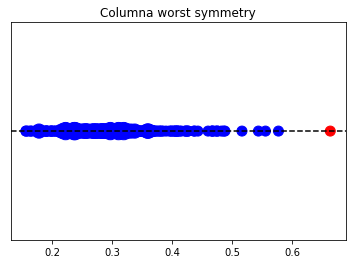

```python
ws = np.array(df_features['worst symmetry'])
edad_unique, counts = np.unique(ws, return_counts=True)

sizes = counts*100
colors = ['blue']*len(edad_unique)
colors[-1] = 'red'

plt.axhline(1, color='k', linestyle='--')
plt.scatter(edad_unique, np.ones(len(edad_unique)), s=sizes, color=colors)
plt.yticks([])
plt.title("Columna worst symmetry")
plt.show()
```

Vemos como están distribuidos los datos y como existe un valor que se sale de una forma 'relativamente significativa' de dicha distribución.

Comprobamos algunas columnas más.

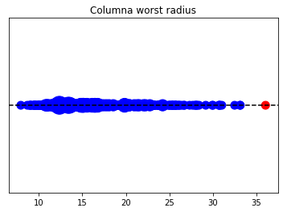

```python
wr = np.array(df_features['worst radius'])
edad_unique, counts = np.unique(wr, return_counts=True)

sizes = counts*100
colors = ['blue']*len(edad_unique)
colors[-1] = 'red'

plt.axhline(1, color='k', linestyle='--')
plt.scatter(edad_unique, np.ones(len(edad_unique)), s=sizes, color=colors)
plt.yticks([])
plt.title("Columna worst radius")
plt.show()
```

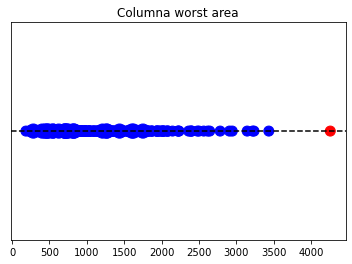

```python
wa = np.array(df_features['worst area'])
edad_unique, counts = np.unique(wa, return_counts=True)

sizes = counts*100
colors = ['blue']*len(edad_unique)
colors[-1] = 'red'

plt.axhline(1, color='k', linestyle='--')
plt.scatter(edad_unique, np.ones(len(edad_unique)), s=sizes, color=colors)
plt.yticks([])
plt.title("Columna worst area")
plt.show()
```

### Eliminación de outliers

Una vez que tenemos identificado que existen algunos valores que se salen de la distribución normal de los datos podemos proceder a eliminar las instancias correspondientes.

Añadimos que para determinar si dichas instancias corresponden realmente a valores anómalos o si estos entran dentro de la normalidad del ambito en el cual se han obtenido estos, se debe de tener conocimiento del área en cuestión.

En nuestro caso procedemos a crear un conjunto con las instancias que contengan valores más extremos de la variable worst area eliminadas.

```python
df_features_outWorstArea = df_features.drop(df_features[df_features['worst area']  > 3500.0].index)
```

```python
print(df_features[df_features['worst area']  > 3500.0].index)
```

```
Int64Index([461], dtype='int64')
```

Se ha eliminado la instancia 461. Como es de suponer esto no influirá en los resultos. El objetivo es demostrar el proceso de detección y eliminación de outliers.

### División del dataset en conjunto de entrenamiento y test

```python
from sklearn.model_selection import train_test_split
```

```python
df_train, df_test = train_test_split(df_features, test_size = 0.3)
```

```python
from sklearn.preprocessing import StandardScaler
```

```python
## Partición de datos sin estandarizar
train_X = df_train.drop(['target'], axis=1)
train_y=pd.DataFrame(df_train['target'])
test_X= df_test.drop(['target'], axis=1)
test_y =pd.DataFrame(df_test['target'])
```

### Escalado de variables

Algunos algoritmos necesitan de unos datos con valores en una misma escalada para que tengan mejor rendimiento. Para cubrir dicha necesidad se le aplican procesos de normalización o estandarización a los datos.

Realizamos una estandarización de nuestros datos con el fin de ver la diferencia de rendimiento de nuestro algoritmo respecto de unos datos no estandarizados.

Añadimos que KNN es particularmente sensible a diferencias en la escala de los datos ya que en sus procesos de clasificación hace uso de distancias.

```python
## Realizamos una partición con datos estandarizados
ss = StandardScaler()
## Primero calcula los valores de la media y desv con fit y después transforma (aplica)
train_X_columns = train_X[train_X.columns]
test_X_columns = test_X[test_X.columns]
train_X_st = ss.fit_transform(train_X_columns)
test_X_st = ss.fit_transform(test_X_columns)
```

### Desbalanceo de clases

Con el fin de ver si existe desbalance de clases en nuestro conjunto de entrenamiento representamos la distribución de las diferentes clases.

```python
train_y.value_counts()
```

```
target
1         247
0         151
dtype: int64
```

Como vemos las clases están ligeramente desproporcionadas.

Aplicamos diferentes técnicas de desbalanceo con el fin de comparar resultados.

#### Undersampling

```python
from imblearn.under_sampling import NearMiss
from collections import Counter

us = NearMiss(sampling_strategy='auto', n_neighbors=3, version=2)
train_X_und, train_y_und = us.fit_resample(train_X, train_y)

## Aplicamos undersampling en conjunto de entrenamiento estandarizado
train_X_und_st, train_y_und_st = us.fit_resample(train_X_st, train_y)


print('Before', train_y.value_counts())
print('After', train_y_und.value_counts())
```

```
Before target
1         247
0         151
dtype: int64
After target
0         151
1         151
dtype: int64
```

#### Oversampling

```python
from imblearn.over_sampling import RandomOverSampler

os =  RandomOverSampler(random_state=0, sampling_strategy='auto')
train_X_ove, train_y_ove = os.fit_resample(train_X, train_y)

## Aplicamos undersampling en conjunto de entrenamiento estandarizado
train_X_ove_st, train_y_ove_st = os.fit_resample(train_X_st, train_y)

print('Before', train_y.value_counts())
print('After', train_y_ove.value_counts())
```

```
Before target
1         247
0         151
dtype: int64
After target
0         247
1         247
dtype: int64
```

#### Combinación Smote-Tomek

Consiste en aplicar simultáneamente los algoritmos de oversampling Smote y undersampling Tomek.

```python
from imblearn.combine import SMOTETomek

os_us = SMOTETomek(random_state = 0)
train_X_com, train_y_com = os_us.fit_resample(train_X, train_y)

## Aplicamos undersampling en conjunto de entrenamiento estandarizado
train_X_com_st, train_y_com_st = os_us.fit_resample(train_X_st, train_y)

print('Before', train_y.value_counts())
print('After', train_y_com.value_counts())
```

```
Before target
1         247
0         151
dtype: int64
After target
0         238
1         238
dtype: int64
```

### Selección del modelo

Como especifíca el enunciado, nuestro modelo sera KNN. KNN es un algoritmo supervisado de clasificación.

Podemos configurar hiperparámetros modificacando características tales como el número de vecinos, la forma de dar peso a las distancias o la métrica de distancias utilizada entre otros.

En nuestro caso crearemos un modelo con número de vecinos = 3 y distancia manhattan. La función de pesos la mantenemos como uniforme.

```python
from sklearn.neighbors import KNeighborsClassifier

knn_ini = KNeighborsClassifier(n_neighbors=3, metric='manhattan')
knn_und_st = KNeighborsClassifier(n_neighbors=3,  metric='manhattan')
knn_ov_st = KNeighborsClassifier(n_neighbors=3,  metric='manhattan')
knn_com_st = KNeighborsClassifier(n_neighbors=3,  metric='manhattan')
```

#### Entrenemos al modelo con todos los conjuntos de datos creados

```python
## Conjunto de datos inicial (sin resampling, sin estandarizar)
knn_ini.fit(train_X,train_y)
## Conjunto de datos con undersampling y estandarizados
knn_und_st.fit(train_X_und_st,train_y_und_st)
## Conjunto de datos con oversampling y estandarizados
knn_ov_st.fit(train_X_ove_st,train_y_ove_st)
## Conjunto de datos con combinación y estandarizados
knn_com_st.fit(train_X_com_st,train_y_com_st)
```

```
KNeighborsClassifier(metric='manhattan', n_neighbors=3)
```

### Evaluación del modelo

```python
## Acurracy, F Score, Precision y ROC score de KNN
from sklearn.metrics import *
prediction=knn_ini.predict(test_X)
print('KNN Model Accuracy :',accuracy_score(prediction,test_y))
print()
print('KNN Model F Scores Micro:',f1_score(prediction,test_y, average='micro'))
print('KNN Model F Scores Macro:',f1_score(prediction,test_y, average='macro'))
print('KNN Model F Scores Weighted:',f1_score(prediction,test_y, average='weighted'))
print()
print('KNN Model Precision Score Micro:',precision_score(prediction,test_y, average='micro'))
print('KNN Model Precision Score Macro:',precision_score(prediction,test_y, average='macro'))
print('KNN Model Precision Score Weighted:',precision_score(prediction,test_y, average='weighted'))
print()
print('KNN Model ROC AUC Score :', roc_auc_score(test_y, knn_ini.predict_proba(test_X)[:, 1]))
print()
print('KNN Model Confusion Matrix: \n', confusion_matrix(test_y, prediction))
print()
print('KNN Model Classification Report: \n', classification_report(test_y, prediction))
```

```
KNN Model Accuracy : 0.9181286549707602

KNN Model F Scores Micro: 0.9181286549707602
KNN Model F Scores Macro: 0.9086817210863595
KNN Model F Scores Weighted: 0.9191592295763311

KNN Model Precision Score Micro: 0.9181286549707602
KNN Model Precision Score Macro: 0.8998509687034277
KNN Model Precision Score Weighted: 0.9226048230362294

KNN Model ROC AUC Score : 0.9377794336810731

KNN Model Confusion Matrix:
 [[ 51  10]
 [  4 106]]

KNN Model Classification Report:
               precision    recall  f1-score   support

           0       0.93      0.84      0.88        61
           1       0.91      0.96      0.94       110

    accuracy                           0.92       171
   macro avg       0.92      0.90      0.91       171
weighted avg       0.92      0.92      0.92       171
```

```python
## Acurracy, F Score, Precision y ROC score de KNN Undersampling Standarized
from sklearn.metrics import *
prediction=knn_und_st.predict(test_X_st)
print('KNN Und Std Model Accuracy :',accuracy_score(prediction,test_y))
print()
print('KNN Und Std Model F Scores Micro:',f1_score(prediction,test_y, average='micro'))
print('KNN Und Std Model F Scores Macro:',f1_score(prediction,test_y, average='macro'))
print('KNN Und Std Model F Scores Weighted:',f1_score(prediction,test_y, average='weighted'))
print()
print('KNN Und Std Model Precision Score Micro:',precision_score(prediction,test_y, average='micro'))
print('KNN Und Std Model Precision Score Macro:',precision_score(prediction,test_y, average='macro'))
print('KNN Und Std Model Precision Score Weighted:',precision_score(prediction,test_y, average='weighted'))
print()
print('KNN Und Std Model ROC AUC Score :', roc_auc_score(test_y, knn_und_st.predict_proba(test_X_st)[:, 1]))
print()
print('KNN Und Std Model Confusion Matrix: \n', confusion_matrix(test_y, prediction))
print()
print('KNN Und Std Model Classification Report: \n', classification_report(test_y, prediction))
```

```
KNN Und Std Model Accuracy : 0.9649122807017544

KNN Und Std Model F Scores Micro: 0.9649122807017544
KNN Und Std Model F Scores Macro: 0.9611834140435835
KNN Und Std Model F Scores Weighted: 0.9651937046004843

KNN Und Std Model Precision Score Micro: 0.9649122807017544
KNN Und Std Model Precision Score Macro: 0.9544709388971684
KNN Und Std Model Precision Score Weighted: 0.9666169895678094

KNN Und Std Model ROC AUC Score : 0.996274217585693

KNN Und Std Model Confusion Matrix:
 [[ 56   5]
 [  1 109]]

KNN Und Std Model Classification Report:
               precision    recall  f1-score   support

           0       0.98      0.92      0.95        61
           1       0.96      0.99      0.97       110

    accuracy                           0.96       171
   macro avg       0.97      0.95      0.96       171
weighted avg       0.97      0.96      0.96       171
```

```python
## Acurracy, F Score, Precision y ROC score de KNN Oversampling Standarized
from sklearn.metrics import *
prediction_ov=knn_ov_st.predict(test_X_st)
print('KNN Over Std Model Accuracy :',accuracy_score(prediction_ov,test_y))
print()
print('KNN Over Std Model F Scores Micro:',f1_score(prediction_ov,test_y, average='micro'))
print('KNN Over Std Model F Scores Macro:',f1_score(prediction_ov,test_y, average='macro'))
print('KNN Over Std Model F Scores Weighted:',f1_score(prediction_ov,test_y, average='weighted'))
print()
print('KNN Over Std Model Precision Score Micro:',precision_score(prediction_ov,test_y, average='micro'))
print('KNN Over Std Model Precision Score Macro:',precision_score(prediction_ov,test_y, average='macro'))
print('KNN Over Std Model Precision Score Weighted:',precision_score(prediction_ov,test_y, average='weighted'))
print()
print('KNN Over Std Model ROC AUC Score :', roc_auc_score(test_y, knn_ov_st.predict_proba(test_X_st)[:, 1]))
print()
print('KNN Over Std Model Confusion Matrix: \n', confusion_matrix(test_y, prediction))
print()
print('KNN Over Std Model Classification Report: \n', classification_report(test_y, prediction_ov))
```

```
KNN Over Std Model Accuracy : 0.9649122807017544

KNN Over Std Model F Scores Micro: 0.9649122807017544
KNN Over Std Model F Scores Macro: 0.962044983722995
KNN Over Std Model F Scores Weighted: 0.9647902680643603

KNN Over Std Model Precision Score Micro: 0.9649122807017544
KNN Over Std Model Precision Score Macro: 0.965424739195231
KNN Over Std Model Precision Score Weighted: 0.9649541140481607

KNN Over Std Model ROC AUC Score : 0.9801788375558866

KNN Over Std Model Confusion Matrix:
 [[ 56   5]
 [  1 109]]

KNN Over Std Model Classification Report:
               precision    recall  f1-score   support

           0       0.94      0.97      0.95        61
           1       0.98      0.96      0.97       110

    accuracy                           0.96       171
   macro avg       0.96      0.97      0.96       171
weighted avg       0.97      0.96      0.97       171
```

```python
## Acurracy, F Score, Precision y ROC score de KNN Combi-sampling Standarized
from sklearn.metrics import *
prediction=knn_com_st.predict(test_X_st)
print('KNN Com Std Model Accuracy :',accuracy_score(prediction,test_y))
print()
print('KNN Com Std Model F Scores Micro:',f1_score(prediction,test_y, average='micro'))
print('KNN Com Std Model F Scores Macro:',f1_score(prediction,test_y, average='macro'))
print('KNN Com Std Model F Scores Weighted:',f1_score(prediction,test_y, average='weighted'))
print()
print('KNN Com Std Model Precision Score Micro:',precision_score(prediction,test_y, average='micro'))
print('KNN Com Std Model Precision Score Macro:',precision_score(prediction,test_y, average='macro'))
print('KNN Com Std Model Precision Score Weighted:',precision_score(prediction,test_y, average='weighted'))
print()
print('KNN Com Std Model ROC AUC Score :', roc_auc_score(test_y, knn_com_st.predict_proba(test_X_st)[:, 1]))
print()
print('KNN Over Std Model Confusion Matrix: \n', confusion_matrix(test_y, prediction))
print()
print('KNN Over Std Model Classification Report: \n', classification_report(test_y, prediction_ov))
```

```
KNN Com Std Model Accuracy : 0.9766081871345029

KNN Com Std Model F Scores Micro: 0.9766081871345029
KNN Com Std Model F Scores Macro: 0.9745156482861401
KNN Com Std Model F Scores Weighted: 0.9766081871345029

KNN Com Std Model Precision Score Micro: 0.9766081871345029
KNN Com Std Model Precision Score Macro: 0.9745156482861401
KNN Com Std Model Precision Score Weighted: 0.9766081871345029

KNN Com Std Model ROC AUC Score : 0.9851713859910582

KNN Over Std Model Confusion Matrix:
 [[ 59   2]
 [  2 108]]

KNN Over Std Model Classification Report:
               precision    recall  f1-score   support

           0       0.94      0.97      0.95        61
           1       0.98      0.96      0.97       110

    accuracy                           0.96       171
   macro avg       0.96      0.97      0.96       171
weighted avg       0.97      0.96      0.97       171
```

### Hiperparametrización Automática

#### Grid Search

La técnica de hiperparametrización automática Grid Search crea y evalua modelos para cada combinación de hiperparámetros. El número de hiperparámetros que queremos optimizar es dado por parámetros.

En nuestro caso y como mencionamos anteriormente vamos a buscar la combinación mas óptima de k, metrica y función de peso usada como predicción.

```python
from sklearn.model_selection import GridSearchCV


grid_values = {'n_neighbors': [1, 2, 3, 6, 24],'weights':['uniform', 'distance'], 'metric':['minkowski', 'manhattan', 'euclidean', 'chebyshev']}
grid_knn_ove_st = GridSearchCV(knn_ov_st, param_grid = grid_values, scoring = 'accuracy' )
grid_knn_ove_st.fit(train_X_ove_st,train_y_ove_st)
y_pred_grid = grid_knn_ove_st.predict(test_X_st)

## Comparamos la mejora

print('KNN Over Std Model Accuracy :',accuracy_score(prediction_ov,test_y))
print('KNN GridSearch Over Std Model Accuracy :',accuracy_score(y_pred_grid,test_y))
print()
print('KNN Over Std Model F Scores Micro:',f1_score(prediction_ov,test_y, average='micro'))
print('KNN Over Std Model F Scores Macro:',f1_score(prediction_ov,test_y, average='macro'))
print('KNN Over Std Model F Scores Weighted:',f1_score(prediction_ov,test_y, average='weighted'))
print('KNN GridSearch Over Std Model F Scores Micro:',f1_score(y_pred_grid,test_y, average='micro'))
print('KNN GridSearch Over Std Model F Scores Macro:',f1_score(y_pred_grid,test_y, average='macro'))
print('KNN GridSearch Over Std Model F Scores Weighted:',f1_score(y_pred_grid,test_y, average='weighted'))
print()
print('KNN Over Std Model Precision Score Micro:',precision_score(prediction_ov,test_y, average='micro'))
print('KNN Over Std Model Precision Score Macro:',precision_score(prediction_ov,test_y, average='macro'))
print('KNN Over Std Model Precision Score Weighted:',precision_score(prediction_ov,test_y, average='weighted'))
print('KNN GridSearch Over Std Model Precision Score Micro:',precision_score(y_pred_grid,test_y, average='micro'))
print('KNN GridSearch Over Std Model Precision Score Macro:',precision_score(y_pred_grid,test_y, average='macro'))
print('KNN GridSearch Over Std Model Precision Score Weighted:',precision_score(y_pred_grid,test_y, average='weighted'))
print()
print('KNN Over Std Model ROC AUC Score :', roc_auc_score(test_y, knn_ov_st.predict_proba(test_X_st)[:, 1]))
print('KNN GridSearch Over Std Model ROC AUC Score :', roc_auc_score(test_y, grid_knn_ove_st.predict_proba(test_X_st)[:, 1]))
print()
print('KNN GridSearch Over Std Model Confusion Matrix: \n', confusion_matrix(test_y, y_pred_grid))
print()
print('KNN GridSearch Over Std Model Classification Report: \n', classification_report(test_y, y_pred_grid))
```

```
KNN Over Std Model Accuracy : 0.9649122807017544
KNN GridSearch Over Std Model Accuracy : 0.9649122807017544

KNN Over Std Model F Scores Micro: 0.9649122807017544
KNN Over Std Model F Scores Macro: 0.962044983722995
KNN Over Std Model F Scores Weighted: 0.9647902680643603
KNN GridSearch Over Std Model F Scores Micro: 0.9649122807017544
KNN GridSearch Over Std Model F Scores Macro: 0.962044983722995
KNN GridSearch Over Std Model F Scores Weighted: 0.9647902680643603

KNN Over Std Model Precision Score Micro: 0.9649122807017544
KNN Over Std Model Precision Score Macro: 0.965424739195231
KNN Over Std Model Precision Score Weighted: 0.9649541140481607
KNN GridSearch Over Std Model Precision Score Micro: 0.9649122807017544
KNN GridSearch Over Std Model Precision Score Macro: 0.965424739195231
KNN GridSearch Over Std Model Precision Score Weighted: 0.9649541140481607

KNN Over Std Model ROC AUC Score : 0.9801788375558866
KNN GridSearch Over Std Model ROC AUC Score : 0.9970193740685545

KNN GridSearch Over Std Model Confusion Matrix:
 [[ 59   2]
 [  4 106]]

KNN GridSearch Over Std Model Classification Report:
               precision    recall  f1-score   support

           0       0.94      0.97      0.95        61
           1       0.98      0.96      0.97       110

    accuracy                           0.96       171
   macro avg       0.96      0.97      0.96       171
weighted avg       0.97      0.96      0.97       171
```